# Final Project Report - Practical Machine Learning Course

## 1. Project Goal

Using devices such as Jawbone Up, Nike FuelBand, and Fitbit it is now possible to collect a large amount of data about personal activity relatively inexpensively. These type of devices are part of the quantified self movement a group of enthusiasts who take measurements about themselves regularly to improve their health, to find patterns in their behavior, or because they are tech geeks.

One thing that people regularly do is quantify how much of a particular activity they do, but they rarely quantify how well they do it. In this project, your goal will be to use data from accelerometers on the belt, forearm, arm, and dumbell of 6 participants. They were asked to perform barbell lifts correctly and incorrectly in 5 different ways.

## 2. Data Sources

The training data for this project are available here:

https://d396qusza40orc.cloudfront.net/predmachlearn/pml-training.csv

The test data are available here:

https://d396qusza40orc.cloudfront.net/predmachlearn/pml-testing.csv

## 3. Analysis and Prediction

First we load the libraries needed for the analysis

```r
library(caret)
library(rpart)
library(rpart.plot)
library(RColorBrewer)
library(rattle)
library(randomForest)
```

Finally, load the same seed with the following line of code:

```r
set.seed(123)
```

### 3.1 Getting the data

The training data set can be found on the following URL:

```r
trainUrl <- "http://d396qusza40orc.cloudfront.net/predmachlearn/pml-training.csv"
```

The testing data set can be found on the following URL:

```r
testUrl <- "http://d396qusza40orc.cloudfront.net/predmachlearn/pml-testing.csv"
```

### 3.2 Load data to memory

```r
training <- read.csv(url(trainUrl), na.strings=c("NA","#DIV/0!",""))
testing <- read.csv(url(testUrl), na.strings=c("NA","#DIV/0!",""))
```

Partioning the training set for cross validation Partioning Training data set into two data sets, 60% for crossTraining, 40% for crossTesting:

```r
inTrain <- createDataPartition(y=training$classe, p=0.6, list=FALSE)
crossTraining <- training[inTrain, ]; crossTesting <- training[-inTrain, ]
dim(crossTraining); dim(crossTesting)
```

```
## [1] 11776   160
```

```
## [1] 7846  160
```

### 3.3 Cleaning the data

The following transformations were used to clean the data:

Transformation 1: Cleaning NearZeroVariance Variables.

```r
nzvData <- nearZeroVar(crossTraining, saveMetrics=TRUE)
```

Use the following code to create another subset without NZV variables:

```r
nzvCrossTraining <- names(crossTraining) %in% c("new_window", "kurtosis_roll_belt", "kurtosis_picth_belt",
"kurtosis_yaw_belt", "skewness_roll_belt", "skewness_roll_belt.1", "skewness_yaw_belt",
"max_yaw_belt", "min_yaw_belt", "amplitude_yaw_belt", "avg_roll_arm", "stddev_roll_arm",
"var_roll_arm", "avg_pitch_arm", "stddev_pitch_arm", "var_pitch_arm", "avg_yaw_arm",
"stddev_yaw_arm", "var_yaw_arm", "kurtosis_roll_arm", "kurtosis_picth_arm",
"kurtosis_yaw_arm", "skewness_roll_arm", "skewness_pitch_arm", "skewness_yaw_arm",
"max_roll_arm", "min_roll_arm", "min_pitch_arm", "amplitude_roll_arm", "amplitude_pitch_arm",
"kurtosis_roll_dumbbell", "kurtosis_picth_dumbbell", "kurtosis_yaw_dumbbell", "skewness_roll_dumbbell",
"skewness_pitch_dumbbell", "skewness_yaw_dumbbell", "max_yaw_dumbbell", "min_yaw_dumbbell",
"amplitude_yaw_dumbbell", "kurtosis_roll_forearm", "kurtosis_picth_forearm", "kurtosis_yaw_forearm",
"skewness_roll_forearm", "skewness_pitch_forearm", "skewness_yaw_forearm", "max_roll_forearm",
"max_yaw_forearm", "min_roll_forearm", "min_yaw_forearm", "amplitude_roll_forearm",
"amplitude_yaw_forearm", "avg_roll_forearm", "stddev_roll_forearm", "var_roll_forearm",
"avg_pitch_forearm", "stddev_pitch_forearm", "var_pitch_forearm", "avg_yaw_forearm",
"stddev_yaw_forearm", "var_yaw_forearm")

crossTraining <- crossTraining[!nzvCrossTraining]

dim(crossTraining)
```

```
## [1] 11776   100
```

Transformation 2: Remove first column of Dataset, which is ID column

```r
crossTraining <- crossTraining[c(-1)]
```

Transformation 3: Cleaning Variables with the threshold of 70% of NA’s:

```r
#Copy crossTraining
training3 <- crossTraining
for(i in 1:length(crossTraining)) {
        #if num of NAs > 70% of total observations
        if( sum( is.na( crossTraining[, i] ) ) /nrow(crossTraining) >= .7 ) {
        for(j in 1:length(training3)) {
            #if the columns are the same, remove the column
            if( length( grep(names(crossTraining[i]), names(training3)[j]) ) ==1)  {
                training3 <- training3[ , -j]
            }
        }
    }
}
```

```r
dim(training3)
```

```
## [1] 11776    58
```

```r
crossTraining <- training3
rm(training3)
```

Perform transformations on crossTesting and testing data sets.

```r
clean1 <- colnames(crossTraining)
clean2 <- colnames(crossTraining[, -58])
crossTesting <- crossTesting[clean1]
testing <- testing[clean2]
```

Examine the result:

```r
dim(crossTesting)
```

```
## [1] 7846   58
```

```r
dim(testing)
```

```
## [1] 20 57
```

Coerce the data into the same type in order to ensure proper functioning of Decision Trees and especially RandomForest Algorithm with the Test data set.

```r
for (i in 1:length(testing) ) {
        for(j in 1:length(crossTraining)) {
        if( length( grep(names(crossTraining[i]), names(testing)[j]) ) ==1)  {
            class(testing[j]) <- class(crossTraining[i])
        }
    }
}

testing <- rbind(crossTraining[2, -58] , testing)
testing <- testing[-1,]
```

Using Decision Tree for prediction:

```r
modelFitDT <- rpart(classe ~ ., data=crossTraining, method="class")
```

View the decision tree with fancy:

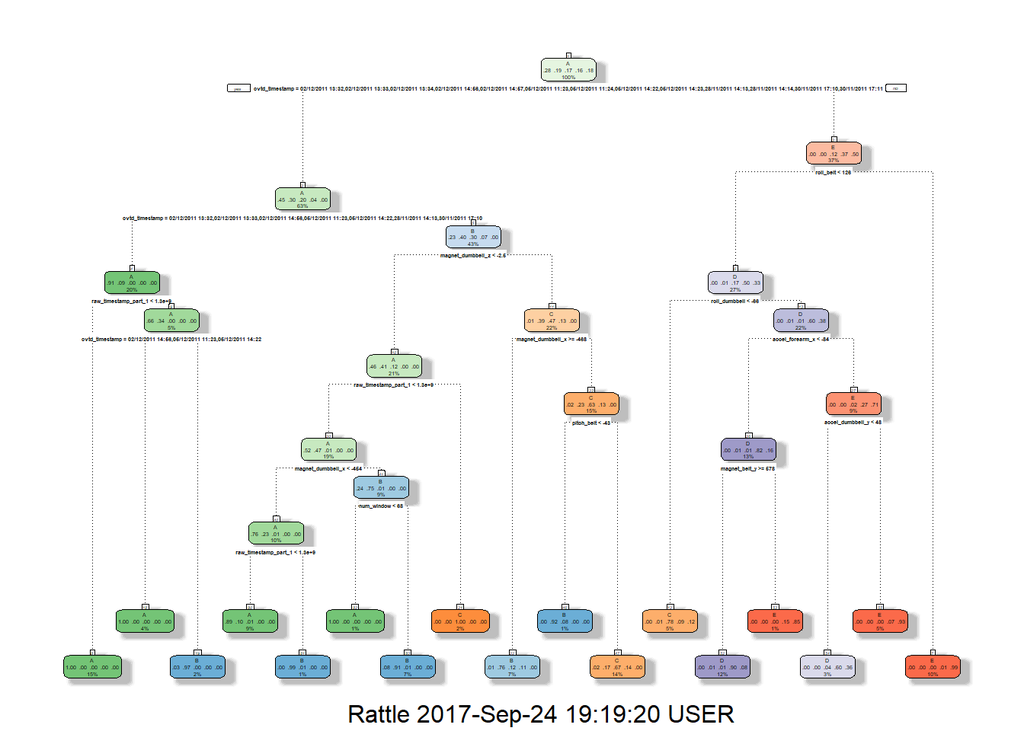

```r
fancyRpartPlot(modelFitDT)
```

### 3.4 Predicting:

Use the model created from Decision Tree for prediction:

```r
predictionsDT <- predict(modelFitDT, crossTesting, type = "class")
```

Use confusion Matrix to test results:

```r
confusionMatrix(predictionsDT, crossTesting$classe)
```

```
## Confusion Matrix and Statistics
##
##           Reference
## Prediction    A    B    C    D    E
##          A 2144   63    9    2    0
##          B   65 1291  102   65    0
##          C   23  157 1233  204   61
##          D    0    7   24  956  189
##          E    0    0    0   59 1192
##
## Overall Statistics
##
##                Accuracy : 0.8687
##                  95% CI : (0.861, 0.8761)
##     No Information Rate : 0.2845
##     P-Value [Acc > NIR] : < 2.2e-16
##
##                   Kappa : 0.834
##  Mcnemar's Test P-Value : NA
##
## Statistics by Class:
##
##                      Class: A Class: B Class: C Class: D Class: E
## Sensitivity            0.9606   0.8505   0.9013   0.7434   0.8266
## Specificity            0.9868   0.9633   0.9313   0.9665   0.9908
## Pos Pred Value         0.9666   0.8477   0.7348   0.8129   0.9528
## Neg Pred Value         0.9844   0.9641   0.9781   0.9505   0.9621
## Prevalence             0.2845   0.1935   0.1744   0.1639   0.1838
## Detection Rate         0.2733   0.1645   0.1572   0.1218   0.1519
## Detection Prevalence   0.2827   0.1941   0.2139   0.1499   0.1594
## Balanced Accuracy      0.9737   0.9069   0.9163   0.8549   0.9087
```

Using Random Forests for prediction:

```r
modelFitRF <- randomForest(classe ~. , data=crossTraining)
```

Predicting us Random Forest:

```r
predictionsRF <- predict(modelFitRF, crossTesting, type = "class")
```

Use confusion Matrix to test results:

```r
confusionMatrix(predictionsRF, crossTesting$classe)
```

```
## Confusion Matrix and Statistics
##
##           Reference
## Prediction    A    B    C    D    E
##          A 2231    0    0    0    0
##          B    1 1518    2    0    0
##          C    0    0 1361    1    0
##          D    0    0    5 1285    1
##          E    0    0    0    0 1441
##
## Overall Statistics
##
##                Accuracy : 0.9987
##                  95% CI : (0.9977, 0.9994)
##     No Information Rate : 0.2845
##     P-Value [Acc > NIR] : < 2.2e-16
##
##                   Kappa : 0.9984
##  Mcnemar's Test P-Value : NA
##
## Statistics by Class:
##
##                      Class: A Class: B Class: C Class: D Class: E
## Sensitivity            0.9996   1.0000   0.9949   0.9992   0.9993
## Specificity            1.0000   0.9995   0.9998   0.9991   1.0000
## Pos Pred Value         1.0000   0.9980   0.9993   0.9954   1.0000
## Neg Pred Value         0.9998   1.0000   0.9989   0.9998   0.9998
## Prevalence             0.2845   0.1935   0.1744   0.1639   0.1838
## Detection Rate         0.2843   0.1935   0.1735   0.1638   0.1837
## Detection Prevalence   0.2843   0.1939   0.1736   0.1645   0.1837
## Balanced Accuracy      0.9998   0.9998   0.9974   0.9992   0.9997
```

## Result

As we can see from the above, Random Forests yielded better Results.

The prediction result for the quiz is as follows:

```r
predict(modelFitRF, testing, type = "class")
```

[output not shown]